# Comparing GPP models

Clay Ford

2025-01-15

First recreate the plots and curves for July 12 that Hannah sent me. Read in the data. Notice it needs to be in long format. I manually edited the spreadsheet you sent me. The `head()` function prints the first 6 rows of data.

```r
library(readxl)
d <- read_xlsx("ExampleData.xlsx", sheet = 2)
# set morning as baseline level
d$time <- factor(d$time, levels = c("morning", "afternoon"))
head(d)
```

```
## # A tibble: 6 × 3
##     par   gpp time
##   <dbl> <dbl> <fct>
## 1  150.  3.66 morning
## 2  348.  5.70 morning
## 3  467.  7.43 morning
## 4  567   8.92 morning
## 5  704. 14.7  morning
## 6  889. 13.5  morning
```

Now fit models for morning and afternoon using the `nls()` function. The `SSmicen()` function is a self-starting [Michaelis-Menten Model](https://en.wikipedia.org/wiki/Michaelis%E2%80%93Menten_kinetics). This model is parameterized like the GPP model.

$$Y = \frac{aX}{b + X} = \frac{GPP_{max}X}{KI + X}$$

```r
# morning model
fit_am <- nls(gpp ~ SSmicmen(par, gpp_max, KI),
              data = subset(d, time == "morning"))
fit_am
```

```
## Nonlinear regression model
##   model: gpp ~ SSmicmen(par, gpp_max, KI)
##    data: subset(d, time == "morning")
## gpp_max      KI
##   19.26  573.77
##  residual sum-of-squares: 27.33
##
## Number of iterations to convergence: 0
## Achieved convergence tolerance: 4.371e-06
```

```r
# afternoon model
fit_pm <- nls(gpp ~ SSmicmen(par, gpp_max, KI),
              data = subset(d, time == "afternoon"))
fit_pm
```

```
## Nonlinear regression model
##   model: gpp ~ SSmicmen(par, gpp_max, KI)
##    data: subset(d, time == "afternoon")
## gpp_max      KI
##   19.83 1514.84
##  residual sum-of-squares: 0.623
##
## Number of iterations to convergence: 0
## Achieved convergence tolerance: 8.637e-08
```

Now recreate the plot.

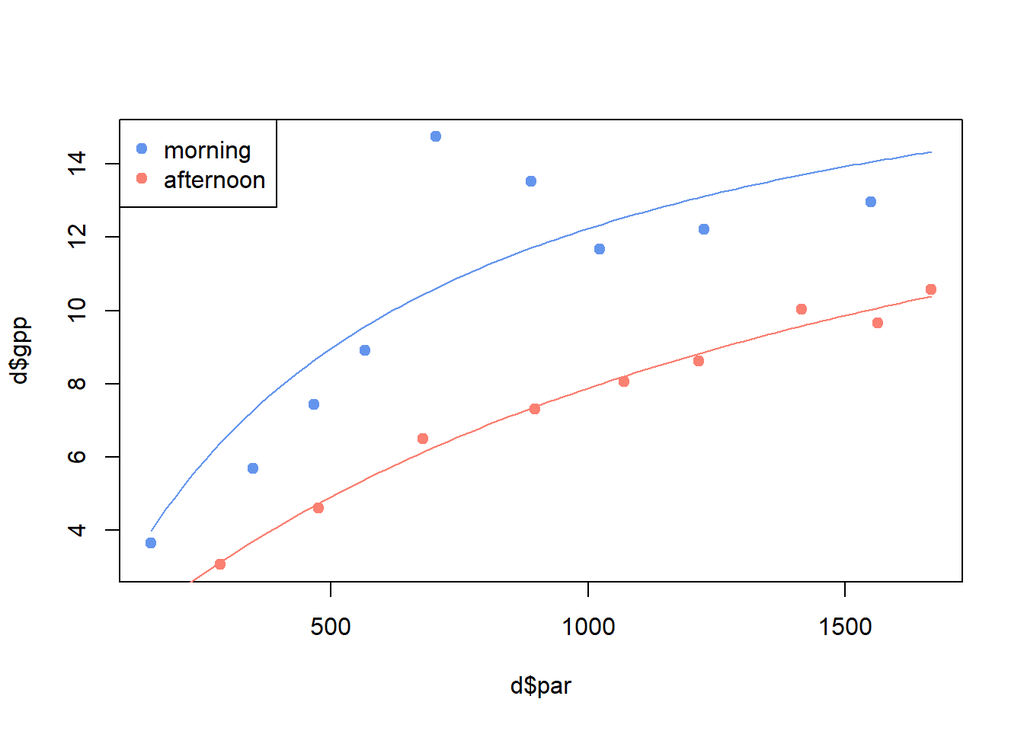

```r
plot(d$par, d$gpp,
     col = ifelse(d$time == "morning", "cornflowerblue", "salmon"), pch = 19)
curve((19.26 * x)/(573.77 + x), add = TRUE,
      col = "cornflowerblue")
curve((19.83 * x)/(1514.84 + x), add = TRUE,
      col = "salmon")
legend("topleft", legend = c("morning", "afternoon"),
       pch = 19,
       col = c("cornflowerblue", "salmon"))
```

Assessing if the fitted curves are different means comparing the KI and GPP<sub>max</sub> values. We can do that by using the time variable as an interaction term. For this we use the `gnls()` function from the {nlme} package that comes installed with R. In the `params` argument we state that we want to compare the “gpp_max” and “KI” coefficients by “time”. The summary output shows two coefficients with “timeafternoon” appended. These are the *differences* in the coefficients.

The coefficient of 0.568 is the difference in GPP<sub>max</sub> values between morning and afternoon. This coefficient has a large standard error (8.461) and hence a small test statistic (0.568 / 8.461 = 0.067). Therefore the p-value is quite large and we conclude we don’t have enough evidence to declare the GPP<sub>max</sub> for afternoon larger than the one for morning. The same conclusion is drawn for the KI coefficient as well.

```r
library(nlme)
fit_both <- gnls(gpp ~ SSmicmen(par, gpp_max, KI),
              data = d,
              params = list(gpp_max + KI ~ time),
              start = c(19.5, 0.6, 1000, 1000))
summary(fit_both)
```

```
## Generalized nonlinear least squares fit
##   Model: gpp ~ SSmicmen(par, gpp_max, KI)
##   Data: d
##        AIC      BIC    logLik
##   69.00377 73.45563 -29.50188
##
## Coefficients:
##                          Value Std.Error  t-value p-value
## gpp_max.(Intercept)    19.2625    3.1478 6.119346  0.0000
## gpp_max.timeafternoon   0.5689    8.4610 0.067236  0.9473
## KI.(Intercept)        573.7807  227.0225 2.527418  0.0242
## KI.timeafternoon      941.0561 1091.9500 0.861812  0.4033
##
##  Correlation:
##                       g_.(I) gpp_m. KI.(I)
## gpp_max.timeafternoon -0.372
## KI.(Intercept)         0.962 -0.358
## KI.timeafternoon      -0.200  0.972 -0.208
##
## Standardized residuals:
##         Min          Q1         Med          Q3         Max
## -1.11499272 -0.46417862 -0.12933482  0.08436811  2.92157204
##
## Residual standard error: 1.412996
## Degrees of freedom: 18 total; 14 residual
```

Start values are required for this model. The first and third are for the intercepts, which in this case are GPP<sub>max</sub> and KI values for the morning group. I basically used a value in between the values observed in the individual models above. The second and fourth are the differences. I eyeballed the model summaries above and estimated a difference in coefficients. For example, 19.8 - 19.2 is about 0.6.

## References

- https://stackoverflow.com/questions/59036555/nls-sslogis-using-a-dummy-variable-as-an-interaction-term-to-compare-two-sigmoi
- R Core Team (2024). *R: A Language and Environment for Statistical Computing*. R Foundation for Statistical Computing, Vienna, Austria. https://www.R-project.org/.
- Pinheiro JC and Bates DM (2000). *Mixed-Effects Models in S and S-PLUS*. Springer.